# Content with notebooks

You can also create content with Jupyter Notebooks. This means that you can include code blocks and their outputs in your book.

## Markdown + notebooks

As it is markdown, you can embed images, HTML, etc into your posts!

You can also $add_{math}$ and

$$ math^{blocks} $$

or

$$ \begin{aligned} \mbox{mean} la_{tex} \\ \\ math blocks \end{aligned} $$

But make sure you \$Escape \$your \$dollar signs \$you want to keep!

## MyST markdown

MyST markdown works in Jupyter Notebooks as well. For more information about MyST markdown, check out [the MyST guide in Jupyter Book](https://jupyterbook.org/content/myst.html), or see [the MyST markdown documentation](https://myst-parser.readthedocs.io/en/latest/).

## Code blocks and outputs

Jupyter Book will also embed your code blocks and output in your book. For example, here's some sample Matplotlib code:

```python
from google.colab import drive
drive.mount('/content/drive')
```

```python
from matplotlib import rcParams, cycler
import matplotlib.pyplot as plt
import numpy as np
plt.ion()
```

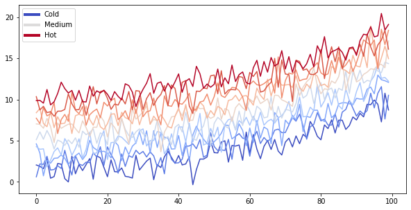

```python
# Fixing random state for reproducibility
np.random.seed(19680801)

N = 10
data = [np.logspace(0, 1, 100) + np.random.randn(100) + ii for ii in range(N)]
data = np.array(data).T
cmap = plt.cm.coolwarm
rcParams['axes.prop_cycle'] = cycler(color=cmap(np.linspace(0, 1, N)))


from matplotlib.lines import Line2D
custom_lines = [Line2D([0], [0], color=cmap(0.), lw=4),
                Line2D([0], [0], color=cmap(.5), lw=4),
                Line2D([0], [0], color=cmap(1.), lw=4)]

fig, ax = plt.subplots(figsize=(10, 5))
lines = ax.plot(data)
ax.legend(custom_lines, ['Cold', 'Medium', 'Hot']);
```

1. Membaca data dari URL ( dataset: liver patients)

```python
import pandas as pd
df = pd.read_csv('https://raw.githubusercontent.com/aisyaturradiah/New-dataset/main/indian_liver_patient.csv')
```

Menampilkan dataset

```python
# Menampilkan informasi data
df.info()
```

```
<class 'pandas.core.frame.DataFrame'>
RangeIndex: 583 entries, 0 to 582
Data columns (total 11 columns):
 #   Column                      Non-Null Count  Dtype
---  ------                      --------------  -----
 0   Age                         583 non-null    int64
 1   Gender                      583 non-null    object
 2   Total_Bilirubin             583 non-null    float64
 3   Direct_Bilirubin            583 non-null    float64
 4   Alkaline_Phosphotase        583 non-null    int64
 5   Alamine_Aminotransferase    583 non-null    int64
 6   Aspartate_Aminotransferase  583 non-null    int64
 7   Total_Protiens              583 non-null    float64
 8   Albumin                     583 non-null    float64
 9   Albumin_and_Globulin_Ratio  579 non-null    float64
 10  Dataset                     583 non-null    int64
dtypes: float64(5), int64(5), object(1)
memory usage: 50.2+ KB
```

```python
df
```

|  | Age | Gender | Total_Bilirubin | Direct_Bilirubin | Alkaline_Phosphotase | Alamine_Aminotransferase | Aspartate_Aminotransferase | Total_Protiens | Albumin | Albumin_and_Globulin_Ratio | Dataset |
| --- | --- | --- | --- | --- | --- | --- | --- | --- | --- | --- | --- |
| 0 | 65 | Female | 0.7 | 0.1 | 187 | 16 | 18 | 6.8 | 3.3 | 0.90 | 1 |
| 1 | 62 | Male | 10.9 | 5.5 | 699 | 64 | 100 | 7.5 | 3.2 | 0.74 | 1 |
| 2 | 62 | Male | 7.3 | 4.1 | 490 | 60 | 68 | 7.0 | 3.3 | 0.89 | 1 |
| 3 | 58 | Male | 1.0 | 0.4 | 182 | 14 | 20 | 6.8 | 3.4 | 1.00 | 1 |
| 4 | 72 | Male | 3.9 | 2.0 | 195 | 27 | 59 | 7.3 | 2.4 | 0.40 | 1 |
| ... | ... | ... | ... | ... | ... | ... | ... | ... | ... | ... | ... |
| 578 | 60 | Male | 0.5 | 0.1 | 500 | 20 | 34 | 5.9 | 1.6 | 0.37 | 2 |
| 579 | 40 | Male | 0.6 | 0.1 | 98 | 35 | 31 | 6.0 | 3.2 | 1.10 | 1 |
| 580 | 52 | Male | 0.8 | 0.2 | 245 | 48 | 49 | 6.4 | 3.2 | 1.00 | 1 |
| 581 | 31 | Male | 1.3 | 0.5 | 184 | 29 | 32 | 6.8 | 3.4 | 1.00 | 1 |
| 582 | 38 | Male | 1.0 | 0.3 | 216 | 21 | 24 | 7.3 | 4.4 | 1.50 | 2 |

583 rows × 11 columns

1. Membuat statistik Diskriptif dari Data (setiap atribut)

a) Menggunakan fungsi describe untuk menampilkan informasi dari kolom numerik

```python
df.describe()
```

|  | Age | Total_Bilirubin | Direct_Bilirubin | Alkaline_Phosphotase | Alamine_Aminotransferase | Aspartate_Aminotransferase | Total_Protiens | Albumin | Albumin_and_Globulin_Ratio | Dataset |
| --- | --- | --- | --- | --- | --- | --- | --- | --- | --- | --- |
| count | 583.000000 | 583.000000 | 583.000000 | 583.000000 | 583.000000 | 583.000000 | 583.000000 | 583.000000 | 579.000000 | 583.000000 |
| mean | 44.746141 | 3.298799 | 1.486106 | 290.576329 | 80.713551 | 109.910806 | 6.483190 | 3.141852 | 0.947064 | 1.286449 |
| std | 16.189833 | 6.209522 | 2.808498 | 242.937989 | 182.620356 | 288.918529 | 1.085451 | 0.795519 | 0.319592 | 0.452490 |
| min | 4.000000 | 0.400000 | 0.100000 | 63.000000 | 10.000000 | 10.000000 | 2.700000 | 0.900000 | 0.300000 | 1.000000 |
| 25% | 33.000000 | 0.800000 | 0.200000 | 175.500000 | 23.000000 | 25.000000 | 5.800000 | 2.600000 | 0.700000 | 1.000000 |
| 50% | 45.000000 | 1.000000 | 0.300000 | 208.000000 | 35.000000 | 42.000000 | 6.600000 | 3.100000 | 0.930000 | 1.000000 |
| 75% | 58.000000 | 2.600000 | 1.300000 | 298.000000 | 60.500000 | 87.000000 | 7.200000 | 3.800000 | 1.100000 | 2.000000 |
| max | 90.000000 | 75.000000 | 19.700000 | 2110.000000 | 2000.000000 | 4929.000000 | 9.600000 | 5.500000 | 2.800000 | 2.000000 |

Statistik Diskriptif dalam data ini yaitu:

b) menggunakan mean, median, modus

```python
# import library
import numpy as np
import pandas as pd
import matplotlib.pyplot as plt

# menentukan dataframe
Age = df["Age"]
Total_Bilirubin = df["Total_Bilirubin"]
Direct_Bilirubin = df["Direct_Bilirubin"]
Alkaline_Phosphotase = df["Alkaline_Phosphotase"]
Alamine_Aminotransferase = df["Alamine_Aminotransferase"]
Aspartate_Aminotransferase= df["Aspartate_Aminotransferase"]
Total_Protiens = df["Total_Protiens"]
Albumin = df["Albumin"]
Albumin_and_Globulin_Ratio = df["Albumin_and_Globulin_Ratio"]
Dataset = df["Dataset"]


# mencari mean, median dan modus

meanA = Age.mean()
medianA =Age.median()
modusA = Age.mode()

meanTB = Total_Bilirubin.mean()
medianTB = Total_Bilirubin.median()
modusTB = Total_Bilirubin.mode()

meanDB = Direct_Bilirubin.mean()
medianDB = Direct_Bilirubin.median()
modusDB = Direct_Bilirubin.mode()

meanAP = Alkaline_Phosphotase.mean()
medianAP = Alkaline_Phosphotase.median()
modusAP = Alkaline_Phosphotase.mode()

meanAA = Alamine_Aminotransferase.mean()
medianAA = Alamine_Aminotransferase.median()
modusAA = Alamine_Aminotransferase.mode()

meanAA = Aspartate_Aminotransferase.mean()
medianAA = Aspartate_Aminotransferase.median()
modusAA = Aspartate_Aminotransferase.mode()

meanTP = Total_Protiens.mean()
medianTP = Total_Protiens.median()
modusTP = Total_Protiens.mode()

meanA = Albumin.mean()
medianA = Albumin.median()
modusA = Albumin.mode()

meanAaGR = Albumin_and_Globulin_Ratio.mean()
medianAaGR= Albumin_and_Globulin_Ratio.median()
modusAaGR = Albumin_and_Globulin_Ratio.mode()

meanD = Dataset.mean()
medianD = Dataset.median()
modusD = Dataset.mode()


# menampilkan ukuran nilai tengah
print("Age -->",'Mean: ',meanA,'Median: ',medianA,'Modus: ',modusA[0])
print("Total Bilirubin-->",'Mean: ',meanTB,'Median: ',medianTB,'Modus: ',modusTB[0])
print("Direct Bilirubin -->",'Mean: ',meanDB,'Median: ',medianDB,'Modus: ',modusDB[0])
print("Alkaline Phosphotase -->",'Mean: ',meanAP,'Median: ',medianAP,'Modus: ',modusAP[0])
print("Alamine Aminotransferase -->",'Mean: ',meanAA,'Median: ',medianAA,'Modus: ',modusAA[0])
print("Aspartate Aminotransferase-->",'Mean: ',meanAA,'Median: ',medianAA,'Modus: ',modusAA[0])
print("Total Protien -->",'Mean: ',meanTP,'Median: ',medianTP,'Modus: ',modusTP[0])
print("Albumin -->",'Mean: ',meanA,'Median: ',medianA,'Modus: ',modusA[0])
print("Albumin and Globulin Ratio -->",'Mean: ',meanAaGR,'Median: ',medianAaGR,'Modus: ',modusAaGR[0])
print("Dataset -->",'Mean: ',meanD,'Median: ',medianD,'Modus: ',modusD[0])

#mmebuat tabel
from prettytable import PrettyTable
tabel = PrettyTable(["", "Age ", "Total Bilirubin", "Direct Bilirubin", "Alkaline Phosphotases", "Alamine Aminotransferase","Aspartate Aminotransferase", "Total Protien", "Albumin", "Albumin and Globulin Ratio","Dataset" ])
tabel.add_row(["Mean", meanA, meanTB, meanDB, meanAP, meanAA, meanAA,meanTP, meanA, meanAaGR, meanD])
tabel.add_row(["Median", medianA, medianTB, medianDB, medianAP, medianAA, medianAA, medianTP, medianA, medianAaGR, medianD])
tabel.add_row(["Modus", modusA, modusTB, modusDB, modusAP, modusAA, modusAA, modusTP, modusA, modusAaGR, modusD])
print(tabel)
```

[output not shown]

1. Mendeskripsikan kemiringan/skewned dari data setiap variabel
- Tabel ditampilkan satu persatu

```
[Text(0.5, 1.0, 'Positive Skewed')]
```

[figure not shown]

```python
import seaborn as sns
sns.distplot(df['Age'], hist=True, kde=True, bins=int (180/5), color= 'darkblue',hist_kws={'edgecolor': 'black'}, kde_kws={'linewidth':4}).set(title='Positive Skewed')
```

```
[Text(0.5, 1.0, 'Positive Skewed')]
```

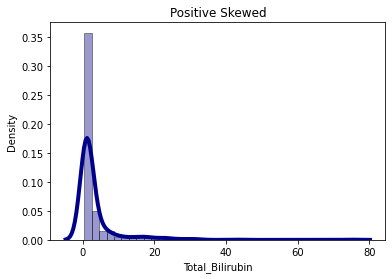

```python
import seaborn as sns
sns.distplot(df['Total_Bilirubin'], hist=True, kde=True, bins=int (180/5), color= 'darkblue',hist_kws={'edgecolor': 'black'}, kde_kws={'linewidth':4}).set(title='Positive Skewed')
```

```
[Text(0.5, 1.0, 'Positive Skewed')]
```

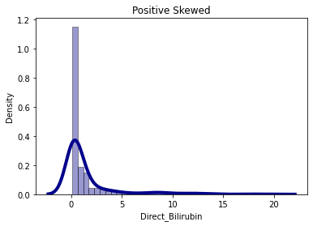

```python
import seaborn as sns
sns.distplot(df['Direct_Bilirubin'], hist=True, kde=True, bins=int (180/5), color= 'darkblue',hist_kws={'edgecolor': 'black'}, kde_kws={'linewidth':4}).set(title='Positive Skewed')
```

```
[Text(0.5, 1.0, 'Positive Skewed')]
```

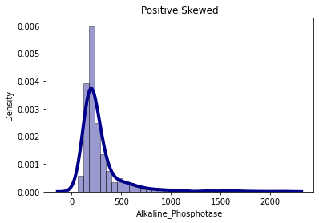

```python
import seaborn as sns
sns.distplot(df['Alkaline_Phosphotase'], hist=True, kde=True, bins=int (180/5), color= 'darkblue',hist_kws={'edgecolor': 'black'}, kde_kws={'linewidth':4}).set(title='Positive Skewed')
```

```
[Text(0.5, 1.0, 'Positive Skewed')]
```

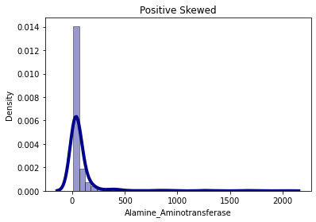

```python
import seaborn as sns
sns.distplot(df['Alamine_Aminotransferase'], hist=True, kde=True, bins=int (180/5), color= 'darkblue',hist_kws={'edgecolor': 'black'}, kde_kws={'linewidth':4}).set(title='Positive Skewed')
```

```
[Text(0.5, 1.0, 'Positive Skewed')]
```

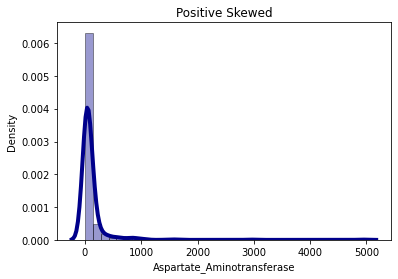

```python
import seaborn as sns
sns.distplot(df['Aspartate_Aminotransferase'], hist=True, kde=True, bins=int (180/5), color= 'darkblue',hist_kws={'edgecolor': 'black'}, kde_kws={'linewidth':4}).set(title='Positive Skewed')
```

```
[Text(0.5, 1.0, 'Negative Skewed')]
```

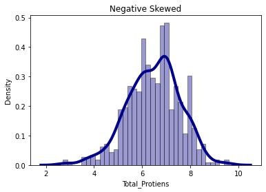

```python
import seaborn as sns
sns.distplot(df['Total_Protiens'], hist=True, kde=True, bins=int (180/5), color= 'darkblue',hist_kws={'edgecolor': 'black'}, kde_kws={'linewidth':4}).set(title='Negative Skewed')
```

```
[Text(0.5, 1.0, 'Positive Skewed')]
```

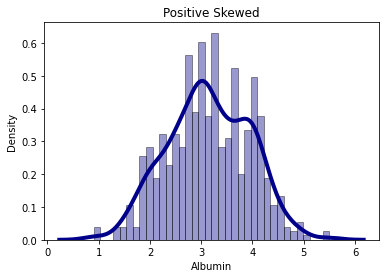

```python
import seaborn as sns
sns.distplot(df['Albumin'], hist=True, kde=True, bins=int (180/5), color= 'darkblue',hist_kws={'edgecolor': 'black'}, kde_kws={'linewidth':4}).set(title='Positive Skewed')
```